# Telco Customer Churn Project

Group7-Bug Tornado

2021-12-07

# Telco Customer Churn

## Description

The Telco customer churn data contains information about a telephone company that provided home phone and Internet services to 7043 customers in California at the end of 2017 Quarter 3. It indicates which customers have left, stayed, or signed up for their service.  
Studying such data can help companies identify the characteristics of lost customers, identify potential, soon-to-be-lost customers and develop appropriate strategies to retain them.  
The dataset is WA_Fn-UseC_-Telco-Customer-Churn.csv.

### variables

- `gender`: Female or Male
- `SeniorCitizen`: customer is a senior citizen or not (Yes, No)
- `Partner`: customer has a partner or not (Yes, No)
- `Dependents`: customer has dependents or not (Yes, No)
- `tenure`: number of months the customer has stayed with the company
- `PhoneService`: customer has a phone service or not (Yes, No)
- `MultipleLines`: customer has multiple lines or not (Yes, No, No phone service)
- `InternetService`: customer’s internet service provider (DSL, Fiber optic, No)
- `OnlineSecurity`: customer has online security or not (Yes, No, No internet service)
- `OnlineBackup`: customer has online backup or not (Yes, No, No internet service)
- `DeviceProtection`: customer has device protection or not (Yes, No, No internet service)
- `TechSupport`: customer has tech support or not (Yes, No, No internet service)
- `StreamingTV`: customer has streaming TV or not (Yes, No, No internet service)
- `StreamingMovies`: customer has streaming movies or not (Yes, No, No internet service)
- `Contract`: contract term of the customer (Month-to-month, One year, Two year)
- `PaperlessBilling`: customer has paperless billing or not (Yes, No)
- `PaymentMethod`: Electronic check, Mailed check, Bank transfer (automatic), Credit card (automatic)
- `MonthlyCharges`: amount charged monthly
- `TotalCharges`: total amount charged
- `Churn`: customer churned or not (Yes or No)

## Logistic Regression

```r
logistic_all = glm(Churn ~ gender + SeniorCitizen + Partner + Dependents + tenure
                         + PhoneService + MultipleLines + InternetService + OnlineSecurity
                         + OnlineBackup + DeviceProtection + TechSupport + StreamingTV
                         + StreamingMovies + Contract + PaperlessBilling + PaymentMethod
                         + MonthlyCharges + TotalCharges, data = customer, family = 'binomial')
summary(logistic_all)
xkabledply(logistic_all)
```

Delete `gender`

```r
logistic_1 = glm(Churn ~ SeniorCitizen + Partner + Dependents + tenure
                         + PhoneService + MultipleLines + InternetService + OnlineSecurity
                         + OnlineBackup + DeviceProtection + TechSupport + StreamingTV
                         + StreamingMovies + Contract + PaperlessBilling + PaymentMethod
                         + MonthlyCharges + TotalCharges, data = customer, family = 'binomial')
summary(logistic_1)
xkabledply(logistic_1)
```

Delete `Partner`

```r
logistic_2 = glm(Churn ~ SeniorCitizen + Dependents + tenure
                         + PhoneService + MultipleLines + InternetService + OnlineSecurity
                         + OnlineBackup + DeviceProtection + TechSupport + StreamingTV
                         + StreamingMovies + Contract + PaperlessBilling + PaymentMethod
                         + MonthlyCharges + TotalCharges, data = customer, family = 'binomial')
summary(logistic_2)
xkabledply(logistic_2)
```

Delete `PhoneService`

```r
logistic_3 = glm(Churn ~ SeniorCitizen + Dependents + tenure
                         + MultipleLines + InternetService + OnlineSecurity
                         + OnlineBackup + DeviceProtection + TechSupport + StreamingTV
                         + StreamingMovies + Contract + PaperlessBilling + PaymentMethod
                         + MonthlyCharges + TotalCharges, data = customer, family = 'binomial')
summary(logistic_3)
xkabledply(logistic_3)
```

Delete `MultipleLines`

```r
logistic_4 = glm(Churn ~ SeniorCitizen + Dependents + tenure
                         + InternetService + OnlineSecurity
                         + OnlineBackup + DeviceProtection + TechSupport + StreamingTV
                         + StreamingMovies + Contract + PaperlessBilling + PaymentMethod
                         + MonthlyCharges + TotalCharges, data = customer, family = 'binomial')
summary(logistic_4)
xkabledply(logistic_4)
```

Delete `OnlineBackup`

```r
logistic_5 = glm(Churn ~ SeniorCitizen + Dependents + tenure
                         + InternetService + OnlineSecurity
                         + DeviceProtection + TechSupport + StreamingTV
                         + StreamingMovies + Contract + PaperlessBilling + PaymentMethod
                         + MonthlyCharges + TotalCharges, data = customer, family = 'binomial')
summary(logistic_5)
xkabledply(logistic_5)
```

Delete `DeviceProtection`

```r
logistic_6 = glm(Churn ~ SeniorCitizen + Dependents + tenure
                         + InternetService + OnlineSecurity
                         + TechSupport + StreamingTV
                         + StreamingMovies + Contract + PaperlessBilling + PaymentMethod
                         + MonthlyCharges + TotalCharges, data = customer, family = 'binomial')
summary(logistic_6)
xkabledply(logistic_6)
```

Delete `PaymentMethod`

```r
logistic_7 = glm(Churn ~ SeniorCitizen + Dependents + tenure
                         + InternetService + OnlineSecurity
                         + TechSupport + StreamingTV
                         + StreamingMovies + Contract + PaperlessBilling
                         + MonthlyCharges + TotalCharges, data = customer, family = 'binomial')
summary(logistic_7)
xkabledply(logistic_7)
```

Now all variables are significant.

```r
expcoeff1 = exp(coef(logistic_7))
summary(expcoeff1)
xkabledply( as.table(expcoeff1), title = "Exponential of coefficients in Churn" )
```

#### Confusion matrix

```r
loadPkg("regclass")
confusion_matrix(logistic_7)
```

```
##            Predicted No Predicted Yes Total
## Actual No          4619           544  5163
## Actual Yes          836          1033  1869
## Total              5455          1577  7032
```

```r
xkabledply( confusion_matrix(logistic_7), title = "Confusion matrix from Logit Model" )
```

Confusion matrix from Logit Model

|  | Predicted No | Predicted Yes | Total |
| --- | --- | --- | --- |
| Actual No | 4619 | 544 | 5163 |
| Actual Yes | 836 | 1033 | 1869 |
| Total | 5455 | 1577 | 7032 |

```r
unloadPkg("regclass")
```

```r
loadPkg("regclass")
cfmatrix1 = confusion_matrix(logistic_7)
accuracy1 <- (cfmatrix1[1,1]+cfmatrix1[2,2])/cfmatrix1[3,3]
precision1 <- cfmatrix1[2,2]/(cfmatrix1[2,2]+cfmatrix1[1,2])
recall1 <- cfmatrix1[2,2]/(cfmatrix1[2,2]+cfmatrix1[2,1])
specificity1 <- cfmatrix1[1,1]/(cfmatrix1[1,1]+cfmatrix1[1,2])
F1_score1 <- 2*(precision1)*(recall1)/(precision1 + recall1)
accuracy1
```

```
## [1] 0.804
```

```r
precision1
```

```
## [1] 0.655
```

```r
recall1
```

```
## [1] 0.553
```

```r
specificity1
```

```
## [1] 0.895
```

```r
F1_score1
```

```
## [1] 0.6
```

From confusion matrix, we can conclude that Accuracy =0.804 Precision=0.655 Recall=0.553 Specificity=0.895 F1 score=0.6

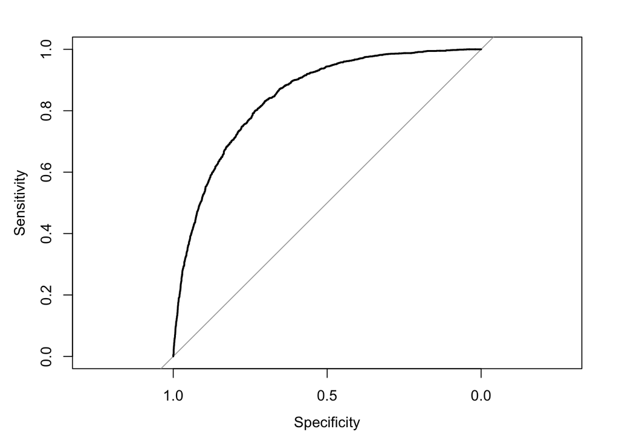

```r
loadPkg("pROC")
prob=predict(logistic_7, type = "response" )
customer$prob=prob
h = roc(Churn~prob, data=customer)
# auc(h)
plot(h)
```

We have here the area-under-curve of 0.846, which is greater than 0.8. The model is considered a good fit.

```r
loadPkg("pscl")
ChurnLogitpr2 = pR2(logistic_7)
```

```
## fitting null model for pseudo-r2
```

```r
ChurnLogitpr2
```

```
##       llh   llhNull        G2  McFadden      r2ML      r2CU
## -2937.855 -4071.678  2267.645     0.278     0.276     0.402
```

```r
unloadPkg("pscl")
```

With the McFadden value of 0.278, which is analogous to the coefficient of determination $R^2$, only about 27.8% of the variations in y is explained by the explanatory variables in the model.

## KNN

```r
customerNum = customer
# convert categorical variable as numeric
for(i in 2:21){
  # tenure, MonthlyCharges, TotalCharges
  if (!(i %in% c(6, 19, 20))){
    customerNum[,i] = as.numeric(customerNum[,i])
  }
}
customerNum$customerID = NULL
str(customerNum)
```

```r
customer_final=customerNum
customer_final$Churn <-  factor(customer_final$Churn)
str(customer_final)
cusKNN <- subset(customer_final, select=c(SeniorCitizen, Partner, Dependents, PaperlessBilling, OnlineSecurity, OnlineBackup, DeviceProtection, TechSupport, Contract, tenure, MonthlyCharges, Churn))
str(cusKNN)
cus_scale = cusKNN
cus_scale[10:11]<- scale(cusKNN[10:11], center = TRUE, scale = TRUE)
cus_scale$Churn <- customer_final$Churn
str(cus_scale)
```

```r
loadPkg("class")
chooseK = function(k, train_set, val_set, train_class, val_class){

  # Build knn with k neighbors considered.
  set.seed(1)
  class_knn = knn(train = train_set,    #<- training set cases
                  test = val_set,       #<- test set cases
                  cl = train_class,     #<- category for classification
                  k = k) #,                #<- number of neighbors considered
                  # use.all = TRUE)       #<- control ties between class assignments. If true, all distances equal to the k-th largest are included

  tab = table(class_knn, val_class)
  #cm = confusionMatrix(class_knn, reference = cus_test_y ) # from caret library
  # print.confusionMatrix(cm)
  #
  #cmaccu = cm$overall['Accuracy']

  # Calculate the accuracy.
  accu = sum(tab[row(tab) == col(tab)]) / sum(tab)
  cbind(k = k, accuracy = accu)
}
```

```r
fullScale = customer_final
fullScale[c(5, 18, 19)]<- scale(fullScale[c(5, 18, 19)], center = TRUE, scale = TRUE)
str(fullScale)
set.seed(1)
customer_sampe <- sample(2, nrow(fullScale), replace=TRUE, prob=c(0.75, 0.25))
cus_train_full <- fullScale[customer_sampe==1, 1:19]
cus_test_full <- fullScale[customer_sampe==2, 1:19]
# y
cus_train_full_y <- fullScale[customer_sampe==1, 20]
cus_test_full_y <- fullScale[customer_sampe==2, 20]
```

Prepossessing the dataset: scale and centered the numerical variables, convert categorical variables as numeric.

```r
str(cus_train_full)
```

```
## 'data.frame':    5185 obs. of  19 variables:
##  $ gender          : num  1 2 2 1 1 1 2 2 2 2 ...
##  $ SeniorCitizen   : num  1 1 1 1 1 1 1 1 1 1 ...
##  $ Partner         : num  2 1 1 1 1 2 1 2 1 2 ...
##  $ Dependents      : num  1 1 1 1 1 1 2 2 1 1 ...
##  $ tenure          : num  -1.2802 0.0643 -1.2394 -1.2394 -0.9135 ...
##  $ PhoneService    : num  1 2 2 2 1 2 2 2 2 2 ...
##  $ MultipleLines   : num  2 1 1 1 2 3 1 1 1 3 ...
##  $ InternetService : num  1 1 1 2 1 2 1 1 3 2 ...
##  $ OnlineSecurity  : num  1 3 3 1 3 1 3 3 2 1 ...
##  $ OnlineBackup    : num  3 1 3 1 1 1 3 1 2 1 ...
##  $ DeviceProtection: num  1 3 1 1 1 3 1 1 2 3 ...
##  $ TechSupport     : num  1 1 1 1 1 3 1 1 2 1 ...
##  $ StreamingTV     : num  1 1 1 1 1 3 1 1 2 3 ...
##  $ StreamingMovies : num  1 1 1 1 1 3 1 1 2 3 ...
##  $ Contract        : num  1 2 1 1 1 1 2 1 3 2 ...
##  $ PaperlessBilling: num  2 1 2 2 1 2 1 2 1 1 ...
##  $ PaymentMethod   : num  3 4 4 3 4 3 1 4 2 2 ...
##  $ MonthlyCharges  : num  -1.162 -0.261 -0.364 0.196 -1.165 ...
##  $ TotalCharges    : num  -0.994 -0.174 -0.96 -0.94 -0.874 ...
```

```r
str(cus_test_full)
```

```
## 'data.frame':    1847 obs. of  19 variables:
##  $ gender          : num  2 1 2 2 2 1 2 2 2 2 ...
##  $ SeniorCitizen   : num  1 1 1 1 1 1 2 1 2 1 ...
##  $ Partner         : num  1 1 1 1 1 1 1 2 1 1 ...
##  $ Dependents      : num  1 1 2 1 2 1 1 1 1 1 ...
##  $ tenure          : num  0.512 -0.995 -0.425 -0.302 1.572 ...
##  $ PhoneService    : num  1 2 2 2 2 2 1 2 2 2 ...
##  $ MultipleLines   : num  2 3 3 1 3 1 2 3 1 1 ...
##  $ InternetService : num  1 2 2 2 2 2 1 1 1 2 ...
##  $ OnlineSecurity  : num  3 1 1 3 3 1 1 3 1 1 ...
##  $ OnlineBackup    : num  1 1 3 1 1 3 1 3 1 1 ...
##  $ DeviceProtection: num  3 3 1 3 3 3 3 3 1 1 ...
##  $ TechSupport     : num  3 1 1 3 1 1 1 3 1 1 ...
##  $ StreamingTV     : num  1 3 3 3 3 1 1 3 1 1 ...
##  $ StreamingMovies : num  1 3 1 3 3 3 3 3 1 1 ...
##  $ Contract        : num  2 1 1 1 3 1 1 3 1 1 ...
##  $ PaperlessBilling: num  1 2 2 2 1 2 2 2 1 2 ...
##  $ PaymentMethod   : num  1 3 2 3 1 3 3 2 1 3 ...
##  $ MonthlyCharges  : num  -0.748 1.158 0.808 1.353 1.393 ...
##  $ TotalCharges    : num  -0.195 -0.645 -0.147 0.178 2.249 ...
```

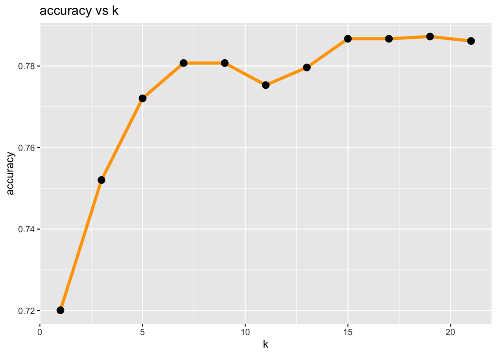

```r
knn_full_different_k = sapply(seq(1, 21, by = 2),  #<- set k to be odd number from 1 to 21
                         function(x) chooseK(x,
                                             train_set = cus_train_full,
                                             val_set = cus_test_full,
                                             train_class = cus_train_full_y,
                                             val_class = cus_test_full_y))

str(knn_full_different_k)
knn_full_different_k = data.frame(k = knn_full_different_k[1,],
                             accuracy = knn_full_different_k[2,])

library("ggplot2")

ggplot(knn_full_different_k,
       aes(x = k, y = accuracy)) +
  geom_line(color = "orange", size = 1.5) +
  geom_point(size = 3) +
  labs(title = "accuracy vs k")
```

```r
xkabledply((knn_full_different_k))
```

Select value `k=15`

```r
pred_full <- knn(train = cus_train_full, test = cus_test_full, cl=cus_train_full_y, k=15)
pred_full
```

```r
loadPkg("gmodels")
churnPredCross <- CrossTable(cus_test_full_y, pred_full, prop.chisq = FALSE)
```

```
##
##
##    Cell Contents
## |-------------------------|
## |                       N |
## |           N / Row Total |
## |           N / Col Total |
## |         N / Table Total |
## |-------------------------|
##
##
## Total Observations in Table:  1847
##
##
##                 | pred_full
## cus_test_full_y |         1 |         2 | Row Total |
## ----------------|-----------|-----------|-----------|
##               1 |      1196 |       169 |      1365 |
##                 |     0.876 |     0.124 |     0.739 |
##                 |     0.841 |     0.398 |           |
##                 |     0.648 |     0.091 |           |
## ----------------|-----------|-----------|-----------|
##               2 |       226 |       256 |       482 |
##                 |     0.469 |     0.531 |     0.261 |
##                 |     0.159 |     0.602 |           |
##                 |     0.122 |     0.139 |           |
## ----------------|-----------|-----------|-----------|
##    Column Total |      1422 |       425 |      1847 |
##                 |     0.770 |     0.230 |           |
## ----------------|-----------|-----------|-----------|
##
##
```

### KNN with selected variables

Prepossessing the dataset: scale and centered the numerical variables, convert categorical variables as numeric.

```r
str(cus_scale)
```

```
## 'data.frame':    7032 obs. of  12 variables:
##  $ SeniorCitizen   : num  1 1 1 1 1 1 1 1 1 1 ...
##  $ Partner         : num  2 1 1 1 1 1 1 1 2 1 ...
##  $ Dependents      : num  1 1 1 1 1 1 2 1 1 2 ...
##  $ PaperlessBilling: num  2 1 2 1 2 2 2 1 2 1 ...
##  $ OnlineSecurity  : num  1 3 3 3 1 1 1 3 1 3 ...
##  $ OnlineBackup    : num  3 1 3 1 1 1 3 1 1 3 ...
##  $ DeviceProtection: num  1 3 1 3 1 3 1 1 3 1 ...
##  $ TechSupport     : num  1 1 1 3 1 1 1 1 3 1 ...
##  $ Contract        : num  1 2 1 2 1 1 1 1 1 2 ...
##  $ tenure          : num  -1.2802 0.0643 -1.2394 0.5124 -1.2394 ...
##  $ MonthlyCharges  : num  -1.162 -0.261 -0.364 -0.748 0.196 ...
##  $ Churn           : Factor w/ 2 levels "1","2": 1 1 2 1 2 2 1 1 2 1 ...
```

```r
set.seed(1)
customer_sampe <- sample(2, nrow(cus_scale), replace=TRUE, prob=c(0.75, 0.25))
cus_train <- cus_scale[customer_sampe==1, 1:11]
cus_test <- cus_scale[customer_sampe==2, 1:11]
# y
cus_train_y <- cus_scale[customer_sampe==1, 12]
cus_test_y <- cus_scale[customer_sampe==2, 12]
```

```r
str(cus_train)
```

```
## 'data.frame':    5185 obs. of  11 variables:
##  $ SeniorCitizen   : num  1 1 1 1 1 1 1 1 1 1 ...
##  $ Partner         : num  2 1 1 1 1 2 1 2 1 2 ...
##  $ Dependents      : num  1 1 1 1 1 1 2 2 1 1 ...
##  $ PaperlessBilling: num  2 1 2 2 1 2 1 2 1 1 ...
##  $ OnlineSecurity  : num  1 3 3 1 3 1 3 3 2 1 ...
##  $ OnlineBackup    : num  3 1 3 1 1 1 3 1 2 1 ...
##  $ DeviceProtection: num  1 3 1 1 1 3 1 1 2 3 ...
##  $ TechSupport     : num  1 1 1 1 1 3 1 1 2 1 ...
##  $ Contract        : num  1 2 1 1 1 1 2 1 3 2 ...
##  $ tenure          : num  -1.2802 0.0643 -1.2394 -1.2394 -0.9135 ...
##  $ MonthlyCharges  : num  -1.162 -0.261 -0.364 0.196 -1.165 ...
```

```r
str(cus_test)
```

```
## 'data.frame':    1847 obs. of  11 variables:
##  $ SeniorCitizen   : num  1 1 1 1 1 1 2 1 2 1 ...
##  $ Partner         : num  1 1 1 1 1 1 1 2 1 1 ...
##  $ Dependents      : num  1 1 2 1 2 1 1 1 1 1 ...
##  $ PaperlessBilling: num  1 2 2 2 1 2 2 2 1 2 ...
##  $ OnlineSecurity  : num  3 1 1 3 3 1 1 3 1 1 ...
##  $ OnlineBackup    : num  1 1 3 1 1 3 1 3 1 1 ...
##  $ DeviceProtection: num  3 3 1 3 3 3 3 3 1 1 ...
##  $ TechSupport     : num  3 1 1 3 1 1 1 3 1 1 ...
##  $ Contract        : num  2 1 1 1 3 1 1 3 1 1 ...
##  $ tenure          : num  0.512 -0.995 -0.425 -0.302 1.572 ...
##  $ MonthlyCharges  : num  -0.748 1.158 0.808 1.353 1.393 ...
```

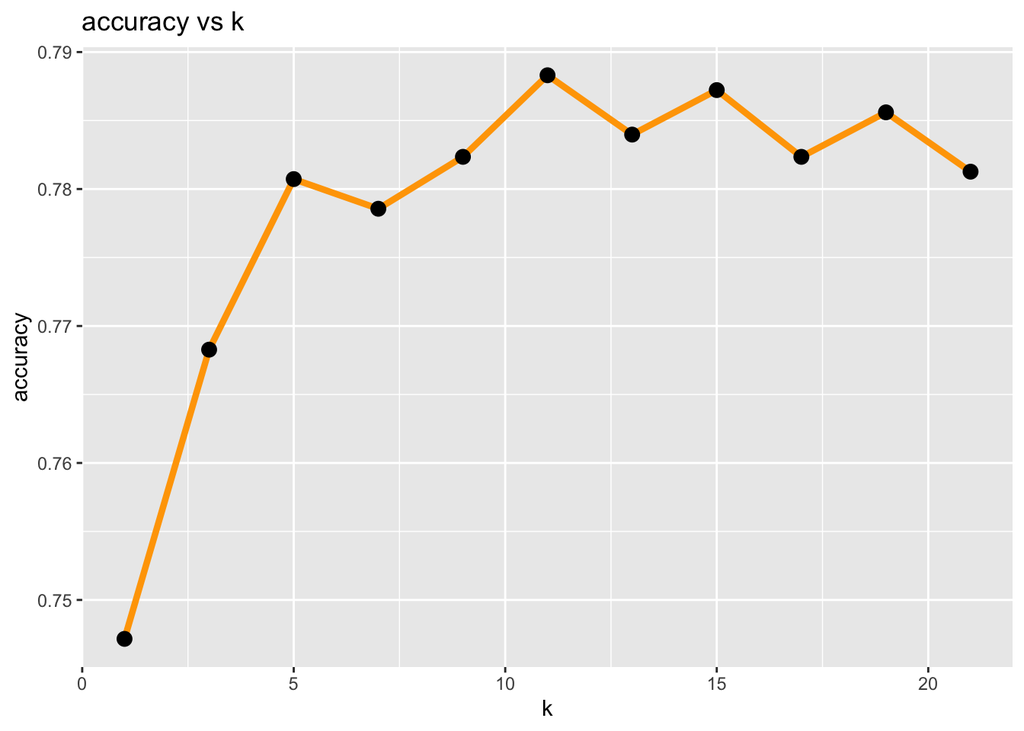

```r
knn_different_k = sapply(seq(1, 21, by = 2),  #<- set k to be odd number from 1 to 21
                         function(x) chooseK(x,
                                             train_set = cus_train,
                                             val_set = cus_test,
                                             train_class = cus_train_y,
                                             val_class = cus_test_y))

# Reformat the results to graph the results.
str(knn_different_k)
knn_different_k = data.frame(k = knn_different_k[1,],
                             accuracy = knn_different_k[2,])

# Plot accuracy vs. k.
# install.packages("ggplot2")
library("ggplot2")

ggplot(knn_different_k,
       aes(x = k, y = accuracy)) +
  geom_line(color = "orange", size = 1.5) +
  geom_point(size = 3) +
  labs(title = "accuracy vs k")
```

```r
xkabledply((knn_different_k))
```

Select value `k=11`

```r
pred <- knn(train = cus_train, test = cus_test, cl=cus_train_y, k=11)
knn.roc.prob <- attr(knn(train = cus_train, test = cus_test, cl=cus_train_y, k=11,prob = T),'prob')
pred
```

```r
library("gmodels")
churnPredCross <- CrossTable(cus_test_y, pred, prop.chisq = FALSE)
```

```
##
##
##    Cell Contents
## |-------------------------|
## |                       N |
## |           N / Row Total |
## |           N / Col Total |
## |         N / Table Total |
## |-------------------------|
##
##
## Total Observations in Table:  1847
##
##
##              | pred
##   cus_test_y |         1 |         2 | Row Total |
## -------------|-----------|-----------|-----------|
##            1 |      1225 |       140 |      1365 |
##              |     0.897 |     0.103 |     0.739 |
##              |     0.829 |     0.378 |           |
##              |     0.663 |     0.076 |           |
## -------------|-----------|-----------|-----------|
##            2 |       252 |       230 |       482 |
##              |     0.523 |     0.477 |     0.261 |
##              |     0.171 |     0.622 |           |
##              |     0.136 |     0.125 |           |
## -------------|-----------|-----------|-----------|
## Column Total |      1477 |       370 |      1847 |
##              |     0.800 |     0.200 |           |
## -------------|-----------|-----------|-----------|
##
##
```

```r
unloadPkg("class")
unloadPkg("gmodels")
```

## Classification Tree

```r
customerNum = customer
# convert categorical variable as numeric
for(i in 2:20){
  # tenure, MonthlyCharges, TotalCharges
  if (!(i %in% c(6, 19, 20))){
    customerNum[,i] = as.numeric(customerNum[,i])
  }
}
customerNum <- subset(customerNum, select = -customerID)
```

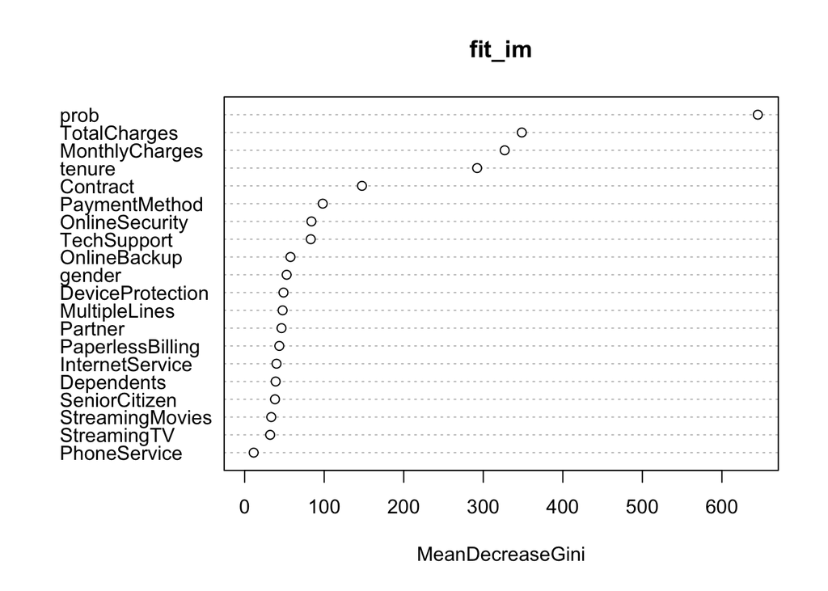

```r
library(randomForest)
fit_im = randomForest(customerNum$Churn~., data=customerNum)
# Create an importance based on mean decreasing gini
# importance(fit_im)
varImpPlot(fit_im)
```

From the sorted importance picture, we can select the top 6 features to build the tree model.

Then, firstly, try to find the best depths.

```r
loadPkg("rpart")
loadPkg("caret")



# create an empty dataframe to store the results from confusion matrices
confusionMatrixResultDf = data.frame( Depth=numeric(0), Accuracy= numeric(0), Sensitivity=numeric(0), Specificity=numeric(0), Pos.Pred.Value=numeric(0), Neg.Pred.Value=numeric(0), Precision=numeric(0), Recall=numeric(0), F1=numeric(0), Prevalence=numeric(0), Detection.Rate=numeric(0), Detection.Prevalence=numeric(0), Balanced.Accuracy=numeric(0), row.names = NULL )

for (deep in 2:8) {
  kfit <- rpart(Churn ~ TotalCharges + MonthlyCharges + tenure + Contract +  OnlineSecurity + PaymentMethod, data=customerNum, method="class", control = list(maxdepth = deep) )
  #
  cm = confusionMatrix( predict(kfit, type = "class"), reference = customerNum[, "Churn"] ) # from caret library
  #
  cmaccu = cm$overall['Accuracy']
  # print( paste("Total Accuracy = ", cmaccu ) )
  #
  cmt = data.frame(Depth=deep, Accuracy = cmaccu, row.names = NULL ) # initialize a row of the metrics
  cmt = cbind( cmt, data.frame( t(cm$byClass) ) ) # the dataframe of the transpose, with k valued added in front
  confusionMatrixResultDf = rbind(confusionMatrixResultDf, cmt)
  # print("Other metrics : ")
}

unloadPkg("caret")
```

The summarized result is here:

```r
xkabledply(confusionMatrixResultDf, title="Churn Classification Trees summary with varying MaxDepth")
```

Churn Classification Trees summary with varying MaxDepth

| Depth | Accuracy | Sensitivity | Specificity | Pos.Pred.Value | Neg.Pred.Value | Precision | Recall | F1 | Prevalence | Detection.Rate | Detection.Prevalence | Balanced.Accuracy |
| --- | --- | --- | --- | --- | --- | --- | --- | --- | --- | --- | --- | --- |
| 2 | 0.742 | 0.750 | 0.719 | 0.880 | 0.510 | 0.880 | 0.750 | 0.810 | 0.734 | 0.551 | 0.626 | 0.735 |
| 3 | 0.781 | 0.930 | 0.370 | 0.803 | 0.657 | 0.803 | 0.930 | 0.862 | 0.734 | 0.683 | 0.851 | 0.650 |
| 4 | 0.781 | 0.930 | 0.370 | 0.803 | 0.657 | 0.803 | 0.930 | 0.862 | 0.734 | 0.683 | 0.851 | 0.650 |
| 5 | 0.793 | 0.908 | 0.473 | 0.827 | 0.651 | 0.827 | 0.908 | 0.865 | 0.734 | 0.667 | 0.807 | 0.691 |
| 6 | 0.793 | 0.908 | 0.473 | 0.827 | 0.651 | 0.827 | 0.908 | 0.865 | 0.734 | 0.667 | 0.807 | 0.691 |
| 7 | 0.793 | 0.908 | 0.473 | 0.827 | 0.651 | 0.827 | 0.908 | 0.865 | 0.734 | 0.667 | 0.807 | 0.691 |
| 8 | 0.793 | 0.908 | 0.473 | 0.827 | 0.651 | 0.827 | 0.908 | 0.865 | 0.734 | 0.667 | 0.807 | 0.691 |

From depths 5, the accuracy is almost same, therefore, we choose depths 5 to build the classification tree model.

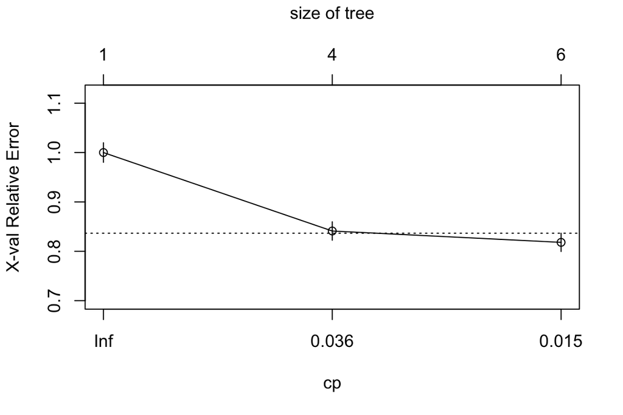

```r
set.seed(1)
Churnfit <- rpart(Churn ~ TotalCharges + MonthlyCharges + tenure + Contract +  OnlineSecurity + PaymentMethod, data=customerNum, method="class", control = list(maxdepth = 5) )

printcp(Churnfit) # display the results
plotcp(Churnfit) # visualize cross-validation results
```

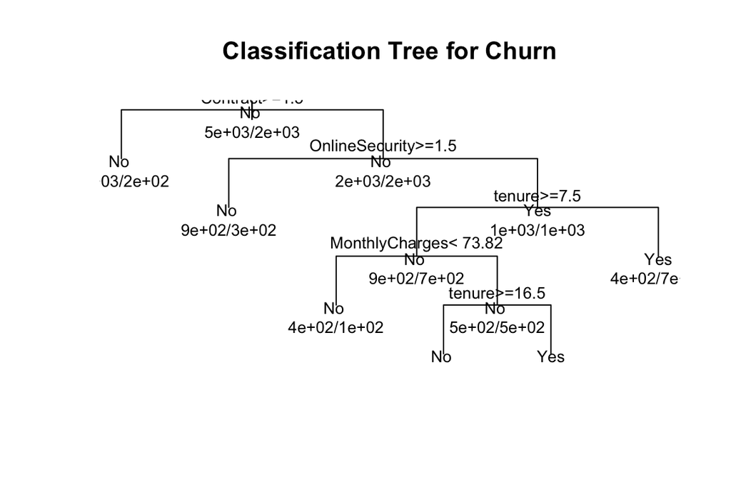

```r
summary(Churnfit) # detailed summary of splits

# plot tree
plot(Churnfit, uniform=TRUE, main="Classification Tree for Churn")
text(Churnfit, use.n=TRUE, all=TRUE, cex=.8)
```

```r
# create attractive postcript plot of tree
post(Churnfit, file = "ChurnTree2.ps", title = "Classification Tree for Churn")
```

```r
loadPkg("caret")
cm = confusionMatrix( predict(Churnfit, type = "class") , reference = customerNum[, "Churn"])
print('Overall: ')
cm$overall
print('Class: ')
cm$byClass
unloadPkg("caret")
```

The overall accuracy is 79.27%. These are the same metrics of sensitivity (also known as recall rate, TP / (TP+FN) ), specificity (TN / (TN+FP) ), F1 score, and others that we used in Logistic Regression and KNN analyses. Indeed, any “classifiers” can use the confustion matrix approach as one of the evaluation tools.

```r
xkabledply(cm$table, "confusion matrix")
```

confusion matrix

|  | No | Yes |
| --- | --- | --- |
| No | 4689 | 984 |
| Yes | 474 | 885 |

Next, we can try two other ways to plot the tree, with library `rpart.plot` and a “fancy” plot using the library `rattle`.

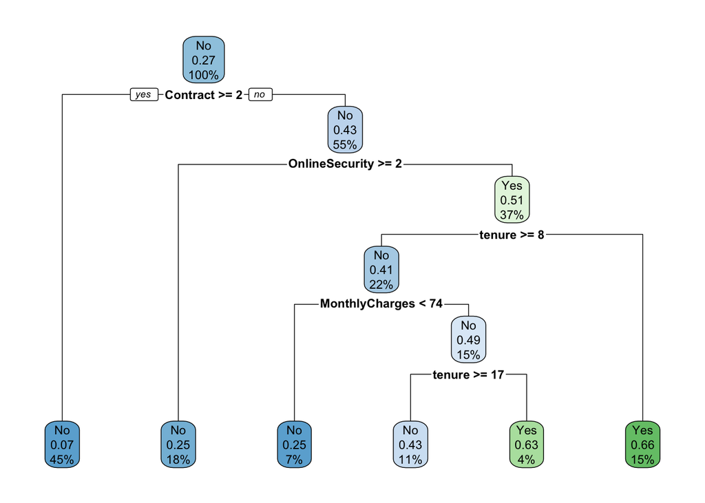

```r
loadPkg("rpart.plot")
rpart.plot(Churnfit)
```

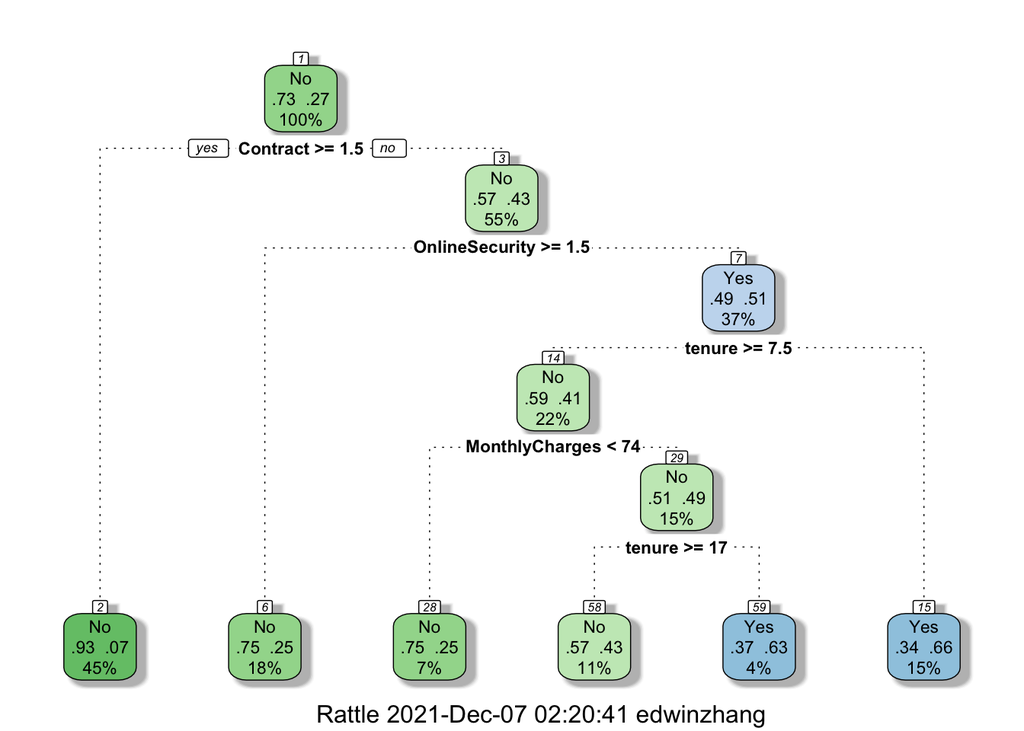

```r
loadPkg("rattle")
fancyRpartPlot(Churnfit)
```

Then we can prune the tree.

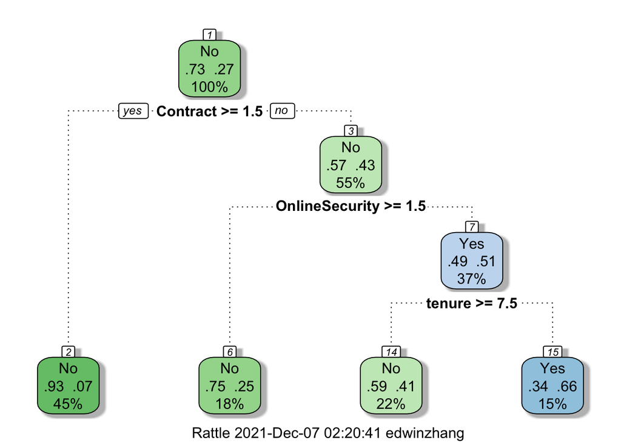

```r
#prune the tree
Churnfit <- prune(Churnfit, cp = Churnfit$cptable[2,"CP"])

# plot the pruned tree
fancyRpartPlot(Churnfit)
```

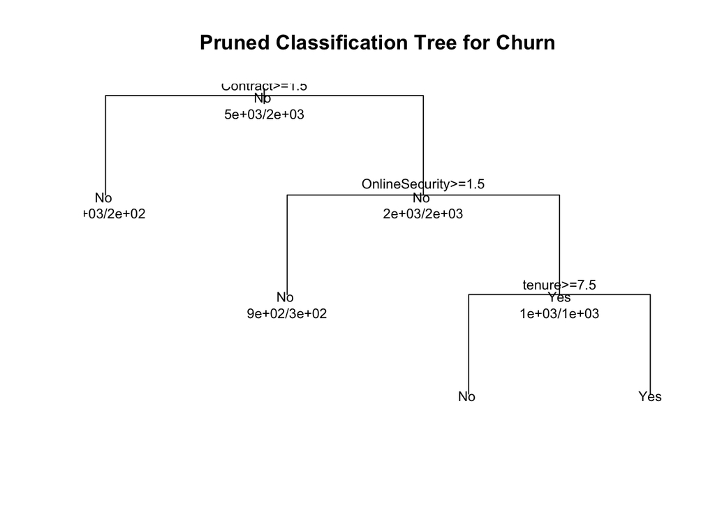

```r
# For boring plot, use codes below instead
plot(Churnfit, uniform=TRUE, main="Pruned Classification Tree for Churn")
text(Churnfit, use.n=TRUE, all=TRUE, cex=.8)
```

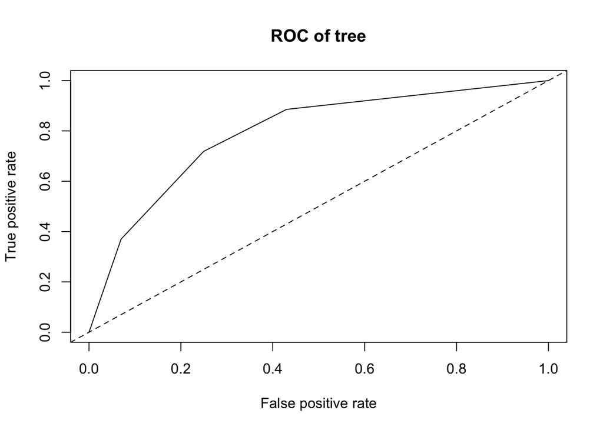

```r
# library(rpart)
# rp <- rpart(Churn ~ ., data = customerNum)
library(ROCR)
tree.predict.prob = predict(Churnfit, type = "prob")
tree.pred <- prediction(tree.predict.prob[, 2], customerNum$Churn)
plot(performance(tree.pred, "tpr", "fpr"), main = "ROC of tree")
auc = performance(tree.pred, 'auc')
slot(auc, 'y.values')
abline(0, 1, lty = 2)
```

## SVM

Firstly, we need to load the package for SVM model training.

```r
# install.packages(tidyverse)
# install.packages(kernlab)
# install.packages(e1071)
# install.packages(caTools)
library(tidyverse)#SVM
library(kernlab)#SVM
library(e1071)#SVM
library(caTools)#Split Data into Test and Train Set
library(ModelMetrics)#confusion matrix
library(ROCR)#ROC plot
```

Then, we set up 75% of total data as the training set, and the rest of them are test set.

```r
dat=subset(customer,select=-c(customerID))
set.seed(123)
split <- sample.split(dat, SplitRatio = 0.75)
# split
train_svm <- subset(dat, split == "TRUE")
test_svm <- subset(dat, split == "FALSE")
```

In this case, we decided to use `tune` function from `e1071` package to train SVM model. There are 4 types of kernel we can use: radial, linear, polynomial and sigmoid. In fact, running these models do cost a lot of time, so we have to change the sample amount of our training set. To save the running time and quickly check the process, we tried to use the less data (200 sample here only) here for showing the template of our process.

### SVM with radial kernel

```r
# tune model to find optimal cost, gamma values
tune.out <- tune(svm, Churn~., data = train_svm[1:200,], kernel = "radial",
                 ranges = list(cost = c(0.1,1,10,100,1000),
                 gamma = c(0.5,1,2,3,4)))
# show best model
tune.out$best.model
```

```
##
## Call:
## best.tune(method = svm, train.x = Churn ~ ., data = train_svm[1:200,
##     ], ranges = list(cost = c(0.1, 1, 10, 100, 1000), gamma = c(0.5,
##     1, 2, 3, 4)), kernel = "radial")
##
##
## Parameters:
##    SVM-Type:  C-classification
##  SVM-Kernel:  radial
##        cost:  10
##
## Number of Support Vectors:  186
```

```r
print('The parameter of best svm model with radial basis kernel is:')
```

```
## [1] "The parameter of best svm model with radial basis kernel is:"
```

```r
tune.out$best.parameters
```

```
##   cost gamma
## 3   10   0.5
```

```r
best_svmfit <- svm(Churn~., data = train_svm, kernel = "radial", gamma = 0.5, cost = 1,probability = TRUE)
```

### SVM with linear kernel

```r
# tune model to find optimal cost, gamma values
tune.out.linear <- tune(svm, Churn~., data = train_svm[1:200,], kernel = "linear",
                 ranges = list(cost = c(0.1,1,10,100,1000)))
# show best model
tune.out.linear$best.model
```

```
##
## Call:
## best.tune(method = svm, train.x = Churn ~ ., data = train_svm[1:200,
##     ], ranges = list(cost = c(0.1, 1, 10, 100, 1000)), kernel = "linear")
##
##
## Parameters:
##    SVM-Type:  C-classification
##  SVM-Kernel:  linear
##        cost:  10
##
## Number of Support Vectors:  78
```

```r
print('The parameter of best svm model with linear kernel is:')
```

```
## [1] "The parameter of best svm model with linear kernel is:"
```

```r
tune.out.linear$best.parameters
```

```
##   cost
## 3   10
```

```r
best_svm_linear_fit <- svm(Churn~., data = train_svm, kernel = "linear", cost = 10,probability = TRUE)
```

### SVM with polynomial kernel

```r
# tune model to find optimal cost, gamma values
tune.out.polynomial <- tune(svm, Churn~., data = train_svm[1:200,], kernel = "polynomial",
                 ranges = list(cost = c(0.1,1,10,100,1000),
                               gamma = c(0.5,1,2,3,4)))
# show best model
tune.out.polynomial$best.model
```

```
##
## Call:
## best.tune(method = svm, train.x = Churn ~ ., data = train_svm[1:200,
##     ], ranges = list(cost = c(0.1, 1, 10, 100, 1000), gamma = c(0.5,
##     1, 2, 3, 4)), kernel = "polynomial")
##
##
## Parameters:
##    SVM-Type:  C-classification
##  SVM-Kernel:  polynomial
##        cost:  0.1
##      degree:  3
##      coef.0:  0
##
## Number of Support Vectors:  91
```

```r
print('The parameter of best svm model with polynomial kernel is:')
```

```
## [1] "The parameter of best svm model with polynomial kernel is:"
```

```r
tune.out.polynomial$best.parameters
```

```
##   cost gamma
## 1  0.1   0.5
```

```r
best_svm_polynomial_fit <- svm(Churn~., data = train_svm, kernel = "polynomial", gamma = 0.1,cost = 0.5,probability = TRUE)
```

### SVM with sigmoid kernel

```r
# tune model to find optimal cost, gamma values
tune.out.sigmoid <- tune(svm, Churn~., data = train_svm[1:200,], kernel = "sigmoid",
                 ranges = list(cost = c(0.1,1,10,100,1000),
                               gamma = c(0.5,1,2,3,4)))
# show best model
tune.out.sigmoid$best.model
```

```
##
## Call:
## best.tune(method = svm, train.x = Churn ~ ., data = train_svm[1:200,
##     ], ranges = list(cost = c(0.1, 1, 10, 100, 1000), gamma = c(0.5,
##     1, 2, 3, 4)), kernel = "sigmoid")
##
##
## Parameters:
##    SVM-Type:  C-classification
##  SVM-Kernel:  sigmoid
##        cost:  0.1
##      coef.0:  0
##
## Number of Support Vectors:  110
```

```r
print('The parameter of best svm model with sigmoid kernel is:')
```

```
## [1] "The parameter of best svm model with sigmoid kernel is:"
```

```r
tune.out.sigmoid$best.parameters
```

```
##   cost gamma
## 1  0.1   0.5
```

```r
best_svm_sigmoid_fit <- svm(Churn~., data = train_svm, kernel = "sigmoid", gamma = 0.5, cost = 0.1,probability = TRUE)
```

### Evaluation for SVM models

After training the best model, we try use the test set to caculate the confusion matrix and relative evaluation score like accuracy, recall rate, F1 socre and so on.

SVM with radial kernel:

```r
library(gmodels)
c.radial <- CrossTable(test_svm$Churn, predict(best_svmfit,test_svm), prop.chisq = FALSE)
```

```
##
##
##    Cell Contents
## |-------------------------|
## |                       N |
## |           N / Row Total |
## |           N / Col Total |
## |         N / Table Total |
## |-------------------------|
##
##
## Total Observations in Table:  2008
##
##
##                | predict(best_svmfit, test_svm)
## test_svm$Churn |        No |       Yes | Row Total |
## ---------------|-----------|-----------|-----------|
##             No |      1342 |       136 |      1478 |
##                |     0.908 |     0.092 |     0.736 |
##                |     0.836 |     0.337 |           |
##                |     0.668 |     0.068 |           |
## ---------------|-----------|-----------|-----------|
##            Yes |       263 |       267 |       530 |
##                |     0.496 |     0.504 |     0.264 |
##                |     0.164 |     0.663 |           |
##                |     0.131 |     0.133 |           |
## ---------------|-----------|-----------|-----------|
##   Column Total |      1605 |       403 |      2008 |
##                |     0.799 |     0.201 |           |
## ---------------|-----------|-----------|-----------|
##
##
```

```r
# validate model performance
# valid <- table(true = test_svm$Churn, pred = predict(best_svmfit,test_svm))
# valid
#method 2(confusion matrix)
loadPkg("caret")

cm_radial = confusionMatrix( predict(best_svmfit,test_svm), reference = test_svm$Churn )
print('Overall of SVM radial kernel: ')
```

```
## [1] "Overall of SVM radial kernel: "
```

```r
cm_radial$overall
```

```
##       Accuracy          Kappa  AccuracyLower  AccuracyUpper   AccuracyNull
##       8.01e-01       4.46e-01       7.83e-01       8.19e-01       7.36e-01
## AccuracyPValue  McnemarPValue
##       5.10e-12       2.83e-10
```

```r
print('Class of SVM radial kernel: ')
```

```
## [1] "Class of SVM radial kernel: "
```

```r
cm_radial$byClass
```

```
##          Sensitivity          Specificity       Pos Pred Value
##                0.908                0.504                0.836
##       Neg Pred Value            Precision               Recall
##                0.663                0.836                0.908
##                   F1           Prevalence       Detection Rate
##                0.871                0.736                0.668
## Detection Prevalence    Balanced Accuracy
##                0.799                0.706
```

SVM with linear kernel:

```r
c.linear <- CrossTable(test_svm$Churn, predict(best_svm_linear_fit,test_svm), prop.chisq = FALSE)
```

```
##
##
##    Cell Contents
## |-------------------------|
## |                       N |
## |           N / Row Total |
## |           N / Col Total |
## |         N / Table Total |
## |-------------------------|
##
##
## Total Observations in Table:  2008
##
##
##                | predict(best_svm_linear_fit, test_svm)
## test_svm$Churn |        No |       Yes | Row Total |
## ---------------|-----------|-----------|-----------|
##             No |      1320 |       158 |      1478 |
##                |     0.893 |     0.107 |     0.736 |
##                |     0.854 |     0.341 |           |
##                |     0.657 |     0.079 |           |
## ---------------|-----------|-----------|-----------|
##            Yes |       225 |       305 |       530 |
##                |     0.425 |     0.575 |     0.264 |
##                |     0.146 |     0.659 |           |
##                |     0.112 |     0.152 |           |
## ---------------|-----------|-----------|-----------|
##   Column Total |      1545 |       463 |      2008 |
##                |     0.769 |     0.231 |           |
## ---------------|-----------|-----------|-----------|
##
##
```

```r
cm_linear = confusionMatrix( predict(best_svm_linear_fit,test_svm), reference = test_svm$Churn )
print('Overall of SVM linear kernel: ')
```

```
## [1] "Overall of SVM linear kernel: "
```

```r
cm_linear$overall
```

```
##       Accuracy          Kappa  AccuracyLower  AccuracyUpper   AccuracyNull
##       8.09e-01       4.88e-01       7.91e-01       8.26e-01       7.36e-01
## AccuracyPValue  McnemarPValue
##       8.54e-15       7.45e-04
```

```r
print('Class of SVM linear kernel: ')
```

```
## [1] "Class of SVM linear kernel: "
```

```r
cm_linear$byClass
```

```
##          Sensitivity          Specificity       Pos Pred Value
##                0.893                0.575                0.854
##       Neg Pred Value            Precision               Recall
##                0.659                0.854                0.893
##                   F1           Prevalence       Detection Rate
##                0.873                0.736                0.657
## Detection Prevalence    Balanced Accuracy
##                0.769                0.734
```

SVM with polynomial kernel:

```r
c.polynomial <- CrossTable(test_svm$Churn, predict(best_svm_polynomial_fit,test_svm), prop.chisq = FALSE)
```

```
##
##
##    Cell Contents
## |-------------------------|
## |                       N |
## |           N / Row Total |
## |           N / Col Total |
## |         N / Table Total |
## |-------------------------|
##
##
## Total Observations in Table:  2008
##
##
##                | predict(best_svm_polynomial_fit, test_svm)
## test_svm$Churn |        No |       Yes | Row Total |
## ---------------|-----------|-----------|-----------|
##             No |      1369 |       109 |      1478 |
##                |     0.926 |     0.074 |     0.736 |
##                |     0.834 |     0.298 |           |
##                |     0.682 |     0.054 |           |
## ---------------|-----------|-----------|-----------|
##            Yes |       273 |       257 |       530 |
##                |     0.515 |     0.485 |     0.264 |
##                |     0.166 |     0.702 |           |
##                |     0.136 |     0.128 |           |
## ---------------|-----------|-----------|-----------|
##   Column Total |      1642 |       366 |      2008 |
##                |     0.818 |     0.182 |           |
## ---------------|-----------|-----------|-----------|
##
##
```

```r
cm_polynomial = confusionMatrix( predict(tune.out.polynomial$best.model,test_svm), reference = test_svm$Churn )
print('Overall of SVM polynomial kernel: ')
```

```
## [1] "Overall of SVM polynomial kernel: "
```

```r
cm_polynomial$overall
```

```
##       Accuracy          Kappa  AccuracyLower  AccuracyUpper   AccuracyNull
##        0.76345        0.38861        0.74423        0.78189        0.73606
## AccuracyPValue  McnemarPValue
##        0.00266        0.78309
```

```r
print('Class of SVM polynomial kernel: ')
```

```
## [1] "Class of SVM polynomial kernel: "
```

```r
cm_polynomial$byClass
```

```
##          Sensitivity          Specificity       Pos Pred Value
##                0.842                0.545                0.838
##       Neg Pred Value            Precision               Recall
##                0.553                0.838                0.842
##                   F1           Prevalence       Detection Rate
##                0.840                0.736                0.620
## Detection Prevalence    Balanced Accuracy
##                0.740                0.693
```

SVM with sigmoid kernel:

```r
c.sigmoid <- CrossTable(test_svm$Churn, predict(best_svm_sigmoid_fit,test_svm), prop.chisq = FALSE)
```

```
##
##
##    Cell Contents
## |-------------------------|
## |                       N |
## |           N / Row Total |
## |           N / Col Total |
## |         N / Table Total |
## |-------------------------|
##
##
## Total Observations in Table:  2008
##
##
##                | predict(best_svm_sigmoid_fit, test_svm)
## test_svm$Churn |        No |       Yes | Row Total |
## ---------------|-----------|-----------|-----------|
##             No |      1098 |       380 |      1478 |
##                |     0.743 |     0.257 |     0.736 |
##                |     0.753 |     0.691 |           |
##                |     0.547 |     0.189 |           |
## ---------------|-----------|-----------|-----------|
##            Yes |       360 |       170 |       530 |
##                |     0.679 |     0.321 |     0.264 |
##                |     0.247 |     0.309 |           |
##                |     0.179 |     0.085 |           |
## ---------------|-----------|-----------|-----------|
##   Column Total |      1458 |       550 |      2008 |
##                |     0.726 |     0.274 |           |
## ---------------|-----------|-----------|-----------|
##
##
```

```r
cm_sigmoid = confusionMatrix( predict(tune.out.sigmoid$best.model,test_svm), reference = test_svm$Churn )
print('Overall of SVM sigmoid kernel: ')
```

```
## [1] "Overall of SVM sigmoid kernel: "
```

```r
cm_sigmoid$overall
```

```
##       Accuracy          Kappa  AccuracyLower  AccuracyUpper   AccuracyNull
##       7.33e-01       1.06e-01       7.13e-01       7.52e-01       7.36e-01
## AccuracyPValue  McnemarPValue
##       6.49e-01       1.97e-60
```

```r
print('Class of SVM sigmoid kernel: ')
```

```
## [1] "Class of SVM sigmoid kernel: "
```

```r
cm_sigmoid$byClass
```

```
##          Sensitivity          Specificity       Pos Pred Value
##                0.947                0.134                0.753
##       Neg Pred Value            Precision               Recall
##                0.477                0.753                0.947
##                   F1           Prevalence       Detection Rate
##                0.839                0.736                0.697
## Detection Prevalence    Balanced Accuracy
##                0.926                0.541
```

```r
unloadPkg("caret")
```

Finally, we plot ROC plot for comparison among the models we built above.

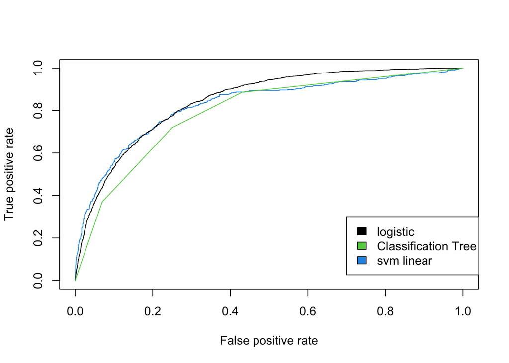

```r
x.svm.linear.prob <- predict(best_svm_linear_fit, type="prob", newdata=test_svm, probability = TRUE)
x.svm.linear.prob.rocr <- prediction(attr(x.svm.linear.prob, "probabilities")[,2], test_svm$Churn)
x.svm.linear.perf <- performance(x.svm.linear.prob.rocr, "tpr","fpr")
plot(x.svm.linear.perf, col=4)

# x.svm.prob <- predict(best_svmfit, type="prob", newdata=test_svm, probability = TRUE)
# x.svm.prob.rocr <- prediction(attr(x.svm.prob, "probabilities")[,2], test_svm$Churn)
# x.svm.perf <- performance(x.svm.prob.rocr, "tpr","fpr")
# plot(x.svm.perf, col=5, add=TRUE)

# x.svm.polynomial.prob <- predict(best_svm_polynomial_fit, type="prob", newdata=test_svm, probability = TRUE)
# x.svm.polynomial.prob.rocr <- prediction(attr(x.svm.prob, "probabilities")[,2], test_svm$Churn)
# x.svm.polynomial.perf <- performance(x.svm.polynomial.prob.rocr, "tpr","fpr")
# plot(x.svm.perf, col=6, add=TRUE)

# x.svm.sigmoid.prob <- predict(best_svm_sigmoid_fit, type="prob", newdata=test_svm, probability = TRUE)
# x.svm.sigmoid.prob.rocr <- prediction(attr(x.svm.prob, "probabilities")[,2], test_svm$Churn)
# x.svm.sigmoid.perf <- performance(x.svm.sigmoid.prob.rocr, "tpr","fpr")
# plot(x.svm.perf, col=7, add=TRUE)

# Draw a legend.
# legend(0.7, 0.3, c( 'logistic','KNN','Classification Tree','svm linear'), 1:4) #with KNN
legend(0.7, 0.3, c( 'logistic','Classification Tree','svm linear'), c(1,3,4))#withou KNN

#logistic
x.glm.prob <- predict(logistic_7, type = "response" )
x.glm.prob.rocr <- prediction(x.glm.prob, customer$Churn)
x.glm.perf <- performance(x.glm.prob.rocr, "tpr","fpr")
plot(x.glm.perf, col=1, add=TRUE)

#tree
x.tree.prob <- prediction(tree.predict.prob[, 2], customerNum$Churn)
plot(performance(x.tree.prob, "tpr", "fpr"), , col=3, add=TRUE)
```

```r
#knn
# x.knn.prob <- prediction(knn.roc.prob, cus_test_y)
# plot(performance(x.knn.prob, "tpr", "fpr"), , col=2, add=TRUE)
```

Even though SVM model won the evaluation according to the accuracy among these model, we still have to choose logistic regression model as our best classification model because of its performance on the ROC Plot and its interpretability.